# Variability in conjugation of the verb *чтить*

The present study deals with the rival forms of the verb *чтить*.

According to the Spelling Dictionary of Russian (RAS), the standard conjugation of this verb is following: *чту, чтишь, чтит, чтим, чтите, чтят / чтут.*

The form of 3PL has two variants, while all others are ones of the IInd conjugation.

The following *questions* arise: 1. How did it happen? 2. Does the verb *чтить* also have other variants for the rest of its forms?

# The hypothesis

The main hypothesis is that at some point the verbs *чтить* and *честь* merged.

# The data

As data we used the samples of conjugation of the verb *чтить* in all possible forms. First we checked the Dictionary for definition of the verb *чтить*. Three definitions are stated:

I. to worship as a heavenly creature

1. *Напротив, он был ревностным христианином, признававшим и чтившим Христа и его учение, проповедовавшим любовь к Богу не только взрослым, но и детям.* [В. Каганов. Можно ли жить своим умом? Об отринутых и проклятых… // «Наука и жизнь», 2008]
2. to feel and show deep respect
2. *Я с детства чтил память деда и увлекался рассказами о его доблести и благородстве.* [Н. А. Бердяев. Автобиография (1917)]

Then we tried to classify the data according to these two meanings and found the third one – to treat as someone:

3. *А ответь-ка мне по правде истинной, как перед богом: за кого меня чтишь?* [В. Я. Шишков. Емельян Пугачев. Книга третья. Ч. 2 (1934-1945)]
4. *Оттого, что дураком меня чтет, а своим умом хвалится, собака, да свой мещанский род возносит.* [Владимир Личутин. Крылатая Серафима (1977)]

Supposedly, this meaning belongs to the verb *честь*. The Dictionary does mention the verb chest as an archaic synonym of the verbs ‘to acknowledge’ and ‘to consider’, and its paradigm fully corresponds to the paradigm of the Ist conjugation.

We looked at the total number of each of 2 forms (Ist and IInd conjugations) in dependency on semantic meaning of each wordform encountered. Numbers 0-4 on the x axis correspond to the following semantics of the studied verb: 0 = ‘to read’ 1 = ‘to worship’ 2 = ‘to respect’ 3 = ‘to treat as’ 4 = ‘to count’ (and several other meanings)

# Data analysis and interpretation

First we tried to find out which of the meanings is the most frequent in the whole data we collected:

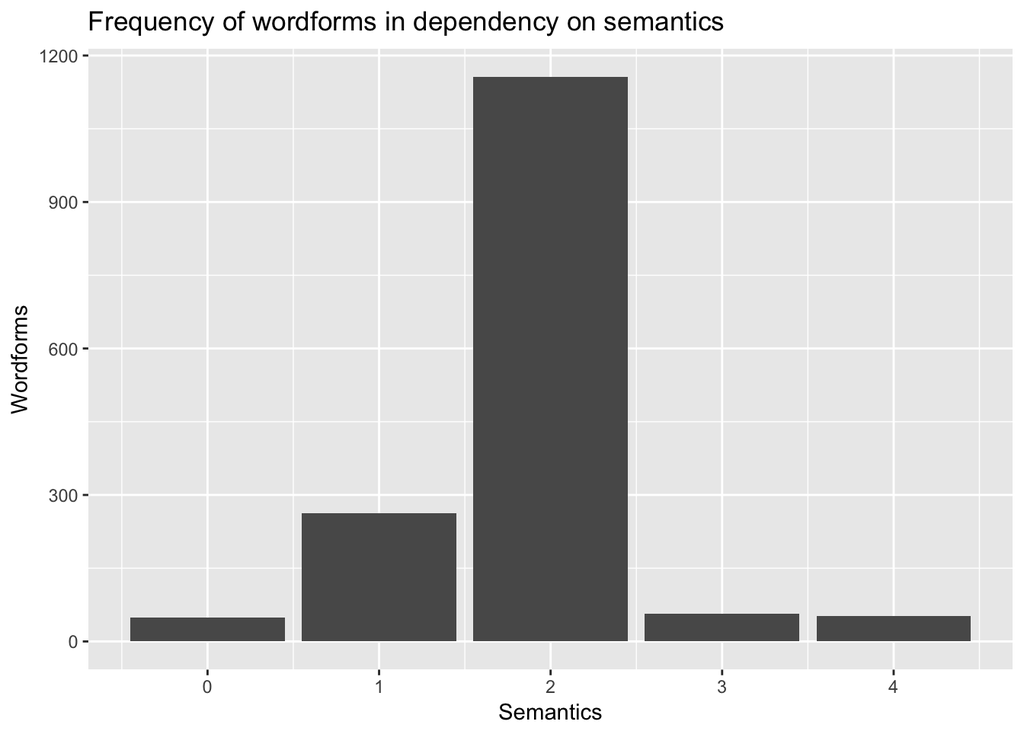

```r
verblist %>%
  ggplot(aes(Semantics, Form))+
  geom_bar(stat="identity") +
  labs(y = "Wordforms",
       x = "Semantics",
       title = "Frequency of wordforms in dependency on semantics")
```

We found out that mostly both of these forms are used in the 2nd meaning = ‘to respect’.

Then we decided to check when the verbs *чтить* and *честь* could merge. For these purposes we made a stack graph. First we rounded and grouped years (‘Created’) by ten in order to unify the format of this factor and to be able to show a more general and clear picture of possible changes. Then we counted the frequency of conjugations’ encounter in each year in percents.

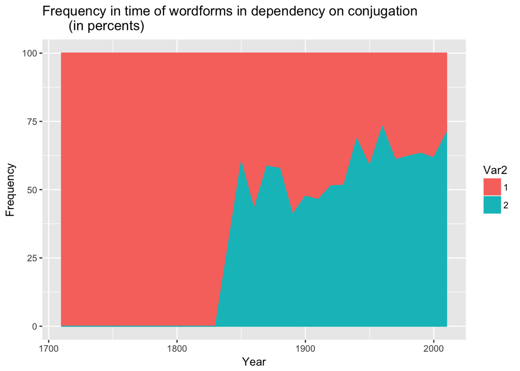

```r
verblist <- mutate(
  verblist,
  bin = floor(as.numeric(substr(as.character(verblist$Created), 0, 4)) / 10) * 10
)
yearsample <- group_by(verblist, bin)
groupped <- as.data.frame(table(yearsample$bin, yearsample$Form))
totals <- aggregate(groupped$Freq, by=list(Year=groupped$Var1), FUN=sum)
groupped <- mutate(groupped, perc = groupped$Freq / totals[groupped$Var1,]$x * 100)

groupped <- groupped[with(groupped, order(Var2)), ]

groupped %>%
  ggplot(aes(as.numeric(as.character(Var1)), perc))+
  geom_area(aes(colour = Var2, fill= Var2), position = 'stack', na.rm = TRUE)+
    labs(y = "Frequency",
       x = "Year",
       title = "Frequency in time of wordforms in dependency on conjugation
       (in percents)")
```

The graph shows that the forms of the Ist conjugation were the only possible ones. The forms of the IInd conjugation started to appear in the mid-1800s and began to prevail in the mid-1900s. However, if we take a closer look at the collected data, we can see that for the Ist conjugation the most numerous one was that of 3SG and 3PL, while the rest of the forms were less frequent.

This serves the reason why we decided to draw the same graph only for 3SG and 3PL forms of both conjugations.

First we made a graph of both conjugations and all the persons.

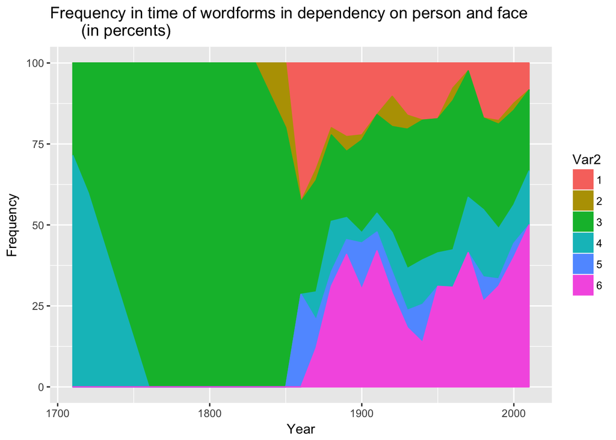

```r
verblist <- mutate(
  verblist,
  bin = floor(as.numeric(substr(as.character(verblist$Created), 0, 4)) / 10) * 10
)
yearsample <- group_by(verblist, bin)
grouppedthird <- as.data.frame(table(yearsample$bin, yearsample$Person.face))
totalthird <- aggregate(grouppedthird$Freq, by=list(Year=grouppedthird$Var1), FUN=sum)
grouppedthird <- mutate(grouppedthird, perc = grouppedthird$Freq / totalthird[grouppedthird$Var1,]$x * 100)
grouppedthird <- as.data.frame(grouppedthird[with(grouppedthird, order(Var2)), ])
grouppedthird %>%
  ggplot(aes(as.numeric(as.character(Var1)), perc))+
  geom_area(aes(colour = Var2, fill= Var2), position = 'stack', na.rm = TRUE)+
  labs(y = "Frequency",
       x = "Year",
       title = "Frequency in time of wordforms in dependency on person and face
       (in percents)")
```

Then we took a close look at each 3SG and 3PL forms:

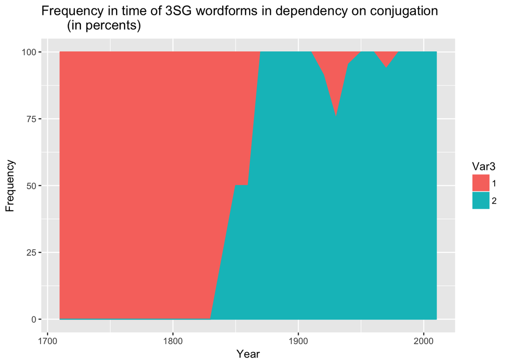

```r
verblist <- mutate(
  verblist,
  bin = floor(as.numeric(substr(as.character(verblist$Created), 0, 4)) / 10) * 10
)
yearsample <- group_by(verblist, bin)
grouppedthird <- as.data.frame(table(yearsample$bin, yearsample$Person.face, yearsample$Form))
grouppedthird <- as.data.frame(grouppedthird[grouppedthird$Var2 == "3" & (grouppedthird$Var3 == "1" | grouppedthird$Var3 == "2"),])
totalthird <- aggregate(grouppedthird$Freq, by=list(Year=grouppedthird$Var1), FUN=sum)
grouppedthird <- mutate(grouppedthird, perc = grouppedthird$Freq / totalthird[grouppedthird$Var1,]$x * 100)

grouppedthird <- as.data.frame(grouppedthird[with(grouppedthird, order(Var2)), ])
grouppedthird %>%
  ggplot(aes(as.numeric(as.character(Var1)), perc))+
  geom_area(aes(colour = Var3, fill= Var3), position = 'stack', na.rm = TRUE)+
  labs(y = "Frequency",
       x = "Year",
       title = "Frequency in time of 3SG wordforms in dependency on conjugation
       (in percents)")
```

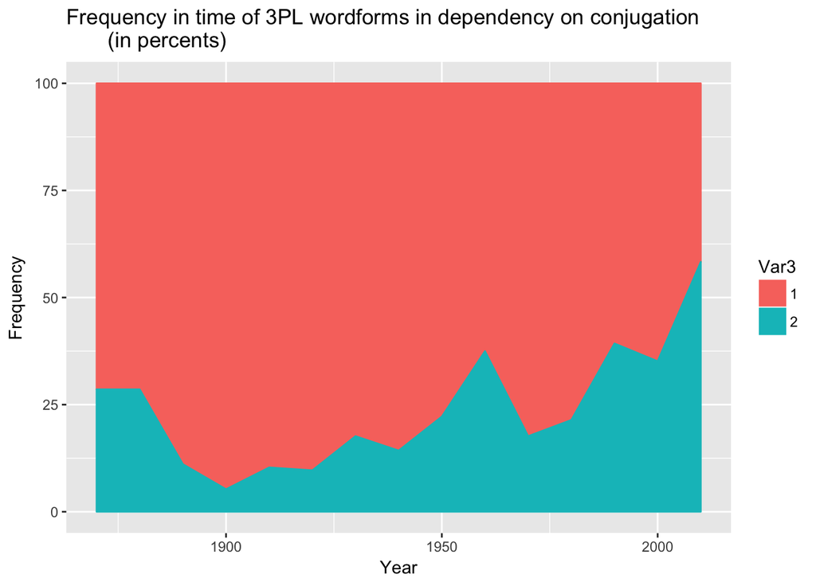

```r
verblist <- mutate(
  verblist,
  bin = floor(as.numeric(substr(as.character(verblist$Created), 0, 4)) / 10) * 10
)
yearsample <- group_by(verblist, bin)
grouppedthird <- as.data.frame(table(yearsample$bin, yearsample$Person.face, yearsample$Form))
grouppedthird <- as.data.frame(grouppedthird[grouppedthird$Var2 == "6" & (grouppedthird$Var3 == "1" | grouppedthird$Var3 == "2"),])
totalthird <- aggregate(grouppedthird$Freq, by=list(Year=grouppedthird$Var1), FUN=sum)
grouppedthird <- mutate(grouppedthird, perc = grouppedthird$Freq / totalthird[grouppedthird$Var1,]$x * 100)

grouppedthird <- as.data.frame(grouppedthird[with(grouppedthird, order(Var2)), ])
grouppedthird %>%
  ggplot(aes(as.numeric(as.character(Var1)), perc))+
  geom_area(aes(colour = Var3, fill= Var3), position = 'stack', na.rm = TRUE)+
    labs(y = "Frequency",
       x = "Year",
       title = "Frequency in time of 3PL wordforms in dependency on conjugation
       (in percents)")
```

Then we checked if the meaning of the verb changed with time.

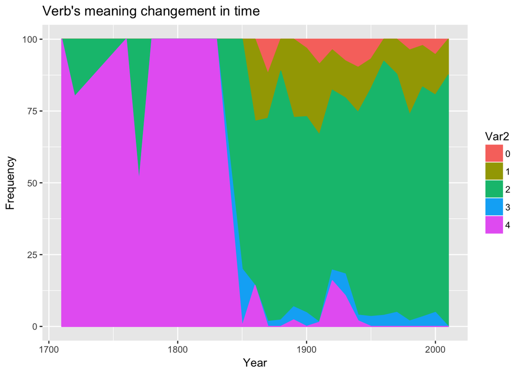

```r
verblist <- mutate(
  verblist,
  bin = floor(as.numeric(substr(as.character(verblist$Created), 0, 4)) / 10) * 10
)
yearsample <- group_by(verblist, bin)
grouppedsem <- as.data.frame(table(yearsample$bin, yearsample$Semantics))
totalsem <- aggregate(grouppedsem$Freq, by=list(Sem=grouppedsem$Var1), FUN=sum)
grouppedsem <- mutate(grouppedsem, perc = grouppedsem$Freq / totalsem[grouppedsem$Var1,]$x * 100)

grouppedsem <- grouppedsem[with(grouppedsem, order(Var2)), ]

grouppedsem %>%
  ggplot(aes(as.numeric(as.character(Var1)), perc))+
  geom_area(aes(colour = Var2, fill= Var2), position = 'stack', na.rm = TRUE)+
    labs(y = "Frequency",
       x = "Year",
       title = "Verb's meaning changement in time")
```

# Results

Our study showed that the verbs *чтить* and *честь* did merge in the middle of the XIX century. Concerning the semantics of the verb, the 4th meaning ‘to count’ prevailes. Then in the middle of the XIX century the 2nd meaning ‘to respect’ became more numerous, and other meanings like ‘to worship’, ‘to treat as’ and ‘to read’.